# Lab 7

Aliza Fassler

10/20/2021

I worked with Sonja Glasser & Justin Roch on this lab.

# **Q1 (1 pt.): What is the sample size, n? Show the code you used for the calculation and remember to check for missing data.**

```r
bill_no_na_gen<-na.omit(dat_pen$bill_length_mm)
length(bill_no_na_gen)
```

```
## [1] 123
```

# **Q2 (1 pt.): What is the sample standard deviation? Show the code you used for the calculation.**

```r
sd(bill_no_na_gen)
```

```
## [1] 3.081857
```

# **Q3 (2 pts.): What are the critical t-values? Show the R code you used for the calculation.**

```r
crit_upper<-qt(0.05/2, 122, lower.tail=FALSE)
crit_lower<-qt(0.05/2, 122, lower.tail=TRUE)
crit_upper
```

```
## [1] 1.9796
```

```r
crit_lower
```

```
## [1] -1.9796
```

# **Q4 (1 pt.): What is the sample standard error? Show the R code you used for the calculation.**

```r
sse_mean = function(x)
 {
  y = na.omit(x)
  return(sd(y)/sqrt(length(y)))
}
gen_se <-sse_mean(bill_no_na_gen)
gen_se
```

```
## [1] 0.2778817
```

# **Q5 (2 pts.): Finally, construct the CI and show the R code you used for the calculation.**

```r
upper_rad<-crit_upper*gen_se
upper_rad
```

```
## [1] 0.5500946
```

```r
lower_rad<-crit_lower*gen_se
lower_rad
```

```
## [1] -0.5500946
```

```r
mean <-mean(bill_no_na_gen)
mean+upper_rad
```

```
## [1] 48.05497
```

```r
mean+lower_rad
```

```
## [1] 46.95478
```

$47.505 \pm 0.550$

# **Q6 (1 pt.): What is the CI?**

# **Q7 (1 pt.): Show the r code you used to call the boot() function.**

```r
require(boot)
```

```r
myboot =
  boot(
    data = bill_no_na_gen,
    statistic = boot_mean,
    R = 10000)
print(myboot)
```

```
##
## ORDINARY NONPARAMETRIC BOOTSTRAP
##
##
## Call:
## boot(data = bill_no_na_gen, statistic = boot_mean, R = 10000)
##
##
## Bootstrap Statistics :
##     original      bias    std. error
## t1* 47.50488 0.001582033   0.2741132
```

# **Q8 (12 pts.): Show the r code you used to calculate the upper and lower 2.5% quantiles.**

```r
quantile(
  myboot$t,
  c(0.025, 0.975))
```

```
##     2.5%    97.5%
## 46.97882 48.04392
```

# **Q9 (5 pts.): Show your completed rarefaction_sampler() function.**

```r
# This clears the current R session's environment
rm(list = ls())

# Re-read my data:
moths = read.csv(here("data", "moths.csv"))
moth_dat = moths[,-1]

rarefaction_sampler = function(input_dat, n_iterations)
{
  n_input_rows = nrow(input_dat)

  results_out = matrix(
    nrow = n_iterations,
    ncol = n_input_rows)

  # The outer loop: runs once for each bootstrap iteration.  index variable is i
  for(i in 1:n_iterations)
  {
    # The inner loop: simulates increasing sampling intensity
    # Sampling intensity ranges from 1 site to the complete count of
    # sites in the input data (n)
    for(j in 1:n_input_rows)
    {
      # sample the input data row indices, with replacement
      rows_j = sample(n_input_rows, size = j, replace=TRUE)

      # Creates a new data matrix
      t1 = input_dat[rows_j, ]

      # Calculates the column sums
      t2 = apply(t1, 2, sum)

      # Counts the number of columns in which any moths were observed
      results_out[i, j] = sum(t2 > 0)
    }
  }
  return(results_out)
}

rarefact = rarefaction_sampler(moth_dat, 100)
head(rarefact)
```

```
##      [,1] [,2] [,3] [,4] [,5] [,6] [,7] [,8] [,9] [,10] [,11] [,12] [,13] [,14]
## [1,]    3    8    7    8    6    8    9   10   10    10     9    10     9    10
## [2,]    5    7    7    8    9   10    9    9    9     9     9    10    10    10
## [3,]    3    7    6   10    8   10   10   10    9    10    10    10    10    10
## [4,]    6    5    9    8   10   10   10   10    9    10    10    10    10    10
## [5,]    6    8    6    9    9    9   10    9   10     9    10    10    10    10
## [6,]    4    7    8    8    8    9   10    9   10     9     9    10    10    10
##      [,15] [,16] [,17] [,18] [,19] [,20] [,21] [,22] [,23] [,24]
## [1,]    10    10    10    10    10     9    10    10    10    10
## [2,]    10    10    10    10     9    10    10    10    10    10
## [3,]    10    10    10    10    10    10    10    10    10    10
## [4,]    10    10    10    10    10    10     9    10    10    10
## [5,]    10    10    10    10    10    10    10    10    10    10
## [6,]    10    10    10    10    10    10    10    10    10    10
```

# **Q10 (1 pt.): What did you find most difficult about building the function?**

The most challenging part was de-bugging and trying to see the differences between versions 1 and 2. It is hard to follow the meaning of complex functions sometimes. I ended up just trying to look at small pieces one at a time to see where it was calling something and where something was not defined within the function.

# **Q11 (4 pts.): Show the code you used to perform the simulations and construct the curve.**

```r
moths = read.csv(here("data", "moths.csv"))
rarefact = rarefaction_sampler(moths[,-1], 10000)
```

```r
rare_mean = apply(rarefact, 2, mean)
rare_quant = apply(rarefact, 2, quantile, probs=c(0.025, 0.975))
rare = t(rbind(rare_mean, rare_quant))
```

# **Q12 (4 pts.): Include your rarefaction curve plot in your report. Show the R-code you used to create your plot.**

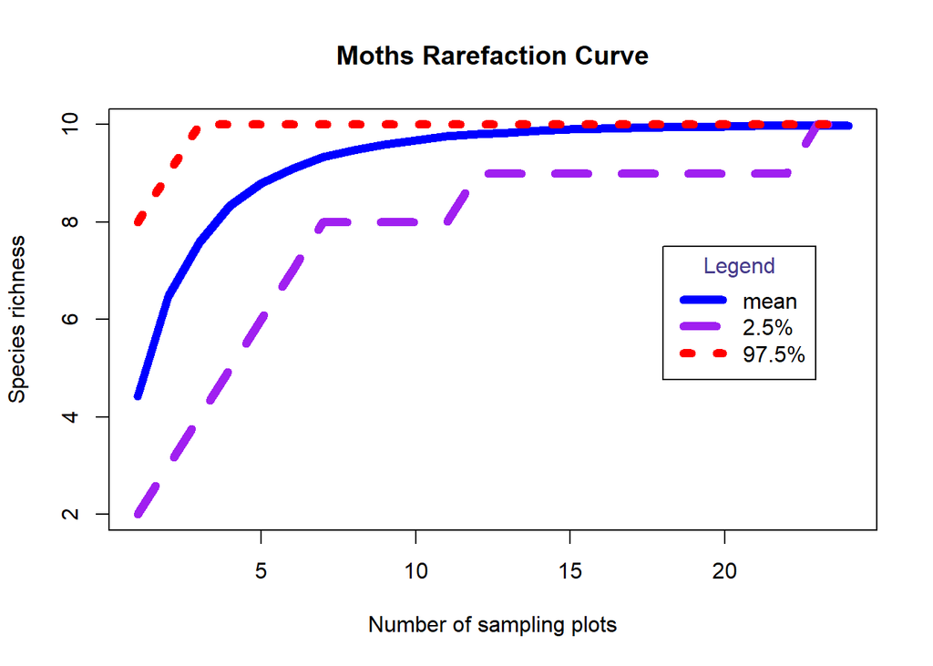

```r
matplot(
  rare,
  type='l',
  col= c("blue", "purple", "red"), lwd = 6,
  xlab='Number of sampling plots',
  ylab='Species richness',
  main='Moths Rarefaction Curve')

legend(x=18, y=7.5,
  legend=c('mean','2.5%','97.5%'),
  lty=c(1,2,4),col= c("blue", "purple", "red"), lwd = 6, inset=c(.1,.1), title = "Legend", title.col = "slateblue4")
```

# **Q13 (2 pts.): About how many sites should you visit if you want to see all of the moth species? Explain your reasoning using your rarefaction curve figure.**

If you wanted to see all of the moth species you would need to visit at least ~15 plots because that is the point at which the species richness levels off. If you visit over 15 plots you are likely to see all of the species.